# Métodos Computacionais para Análise de Risco

25 de junho de 2018

## Trabalho Final - Mateus e Leonardo

## Banco ustermlife

O Banco de Dados selecionado foi originado da Survey of Consumer Finances (SCF) de 2004 que é uma pesquisa que obtem vários dados familiares e individuais relativos a renda. Abaixo as variáveis presentes:

```
##  [1] "Gender"          "Age"             "MarStat"
##  [4] "Education"       "Ethnicity"       "SmarStat"
##  [7] "Sgender"         "Sage"            "Seducation"
## [10] "NumHH"           "Income"          "TotIncome"
## [13] "Charity"         "Face"            "FaceCVLifePol"
## [16] "CashCVLifePol"   "BorrowCVLifePol" "NetValue"
```

Neste trabalho, a variável de interesse será a Renda (Income).

## Análise Descritiva

A variável renda apresenta alto grau de dispersão, por isso durante todo o trabalho, iremos trabalhar com o log(renda). O Histograma da variável log(renda) apresenta um comportamento semelhante ao da distribuição normal.

```
##     Min.  1st Qu.   Median     Mean  3rd Qu.     Max.
##      260    28000    54000   321022   106000 75000000
```

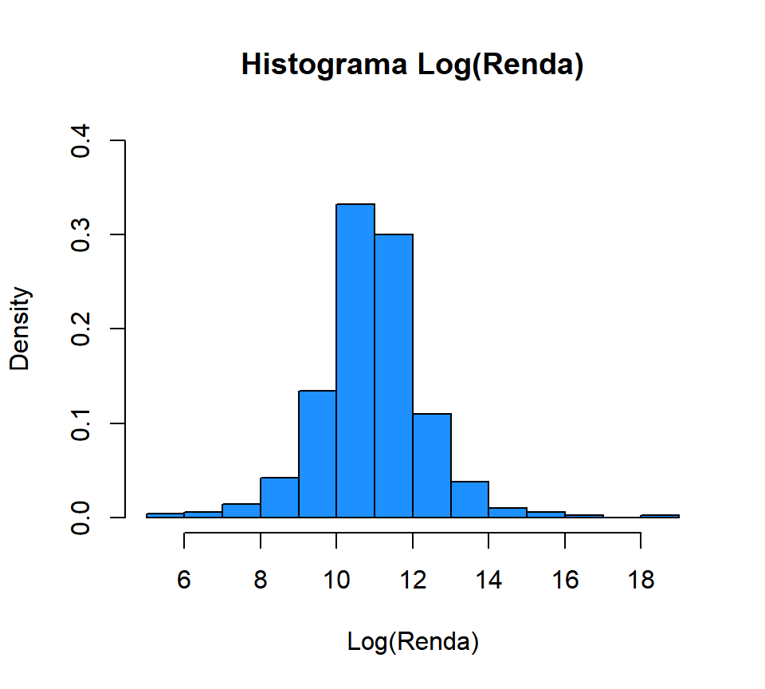

## Análise Descritiva - Sexo

Primeiramente, deve-se ter noção que a quantidade de homens respondendo a pesquisa é bastante superior a de mulheres, sendo assim, há uma maior variabilidade das respostas entre as mulheres.

```
##           mulheres homens
## proporção     17.4   82.6
```

Ao analisarmos as média das rendas, somos levados a acreditar que as mulheres recebem mais do que os homens.

```
##             mulheres   homens
## média renda 914499.2 196003.7
```

## Análise Descritiva - Log(Renda) x Sexo

Porém ao analisarmos o boxplot do log da renda em relação ao sexo, vê-se que as mulheres recebem, no geral, menos do que os homens.

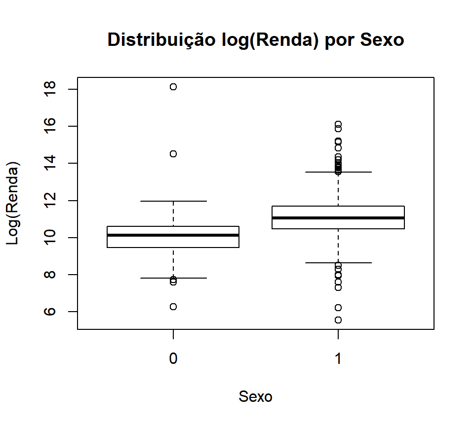

## Análise Descritiva - Idade

Vêmos que a idade dos entrevistados é bem espalhada, tendo 50% dos dados concentrados entre as idades 37 e 58 anos.

```
##    Min. 1st Qu.  Median    Mean 3rd Qu.    Max.
##   20.00   37.00   47.00   47.16   58.00   85.00
```

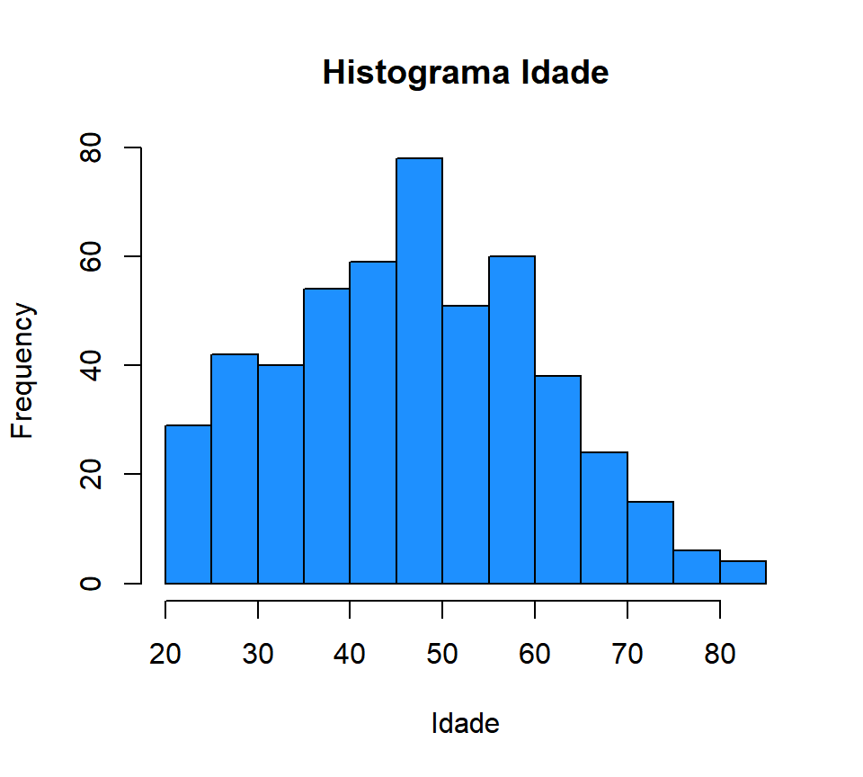

## Análise Descritiva - Log(Renda) x Idade

É possível perceber uma tendencia de aumento nos rendimentos pela idade.

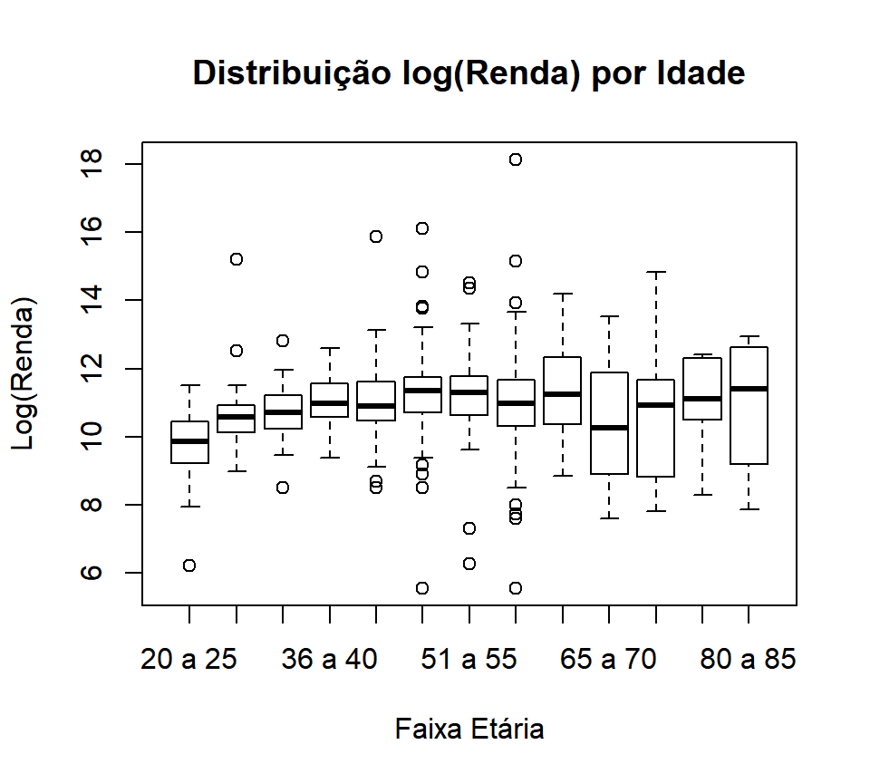

## Análise Descritiva - Escolaridade

A variável Educação apresenta o número de anos que a pessoa passou estudando, podemos observar que a média e a mediana estão muito próximas. Entre 13 a 14 anos a pessoa se forma no Ensino médio nos EUA. Sendo assim, percebemos que aproximadamente 50% dos entrevistados concluíram o ensino médio.

```
##    Min. 1st Qu.  Median    Mean 3rd Qu.    Max.
##    2.00   12.00   14.00   14.06   16.00   17.00
```

Como de 2 a 5 e de 6 a 10 anos representam uma parcela pequena na massa, estes foram agrupados

```
##           2 a 5 6 a 10 11 a 14 15 a 17
## proporção   2.8    4.6      43    49.6
```

## Análise Descritiva - Log(Renda) x Escolaridade

Percebemos uma tendencia de aumento dos rendimentos de acordo com os anos de estudos.

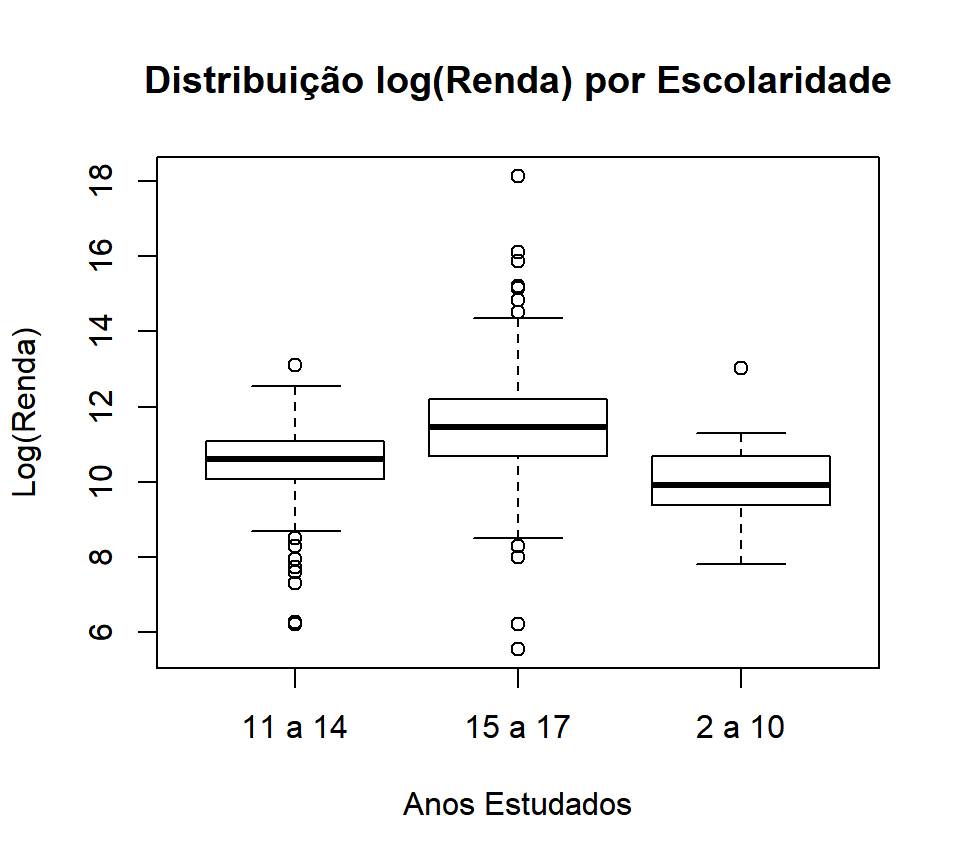

## Análise Descritiva - Log (Renda) X Estado Civil

Tem-se que a maioria dos entrevistados são casados, sendo que estes apresentam maiores rendas anuais.

```
##           casado(a) morando com o parceiro(a) outra forma
## proporção      66.6                       6.2        27.2
```

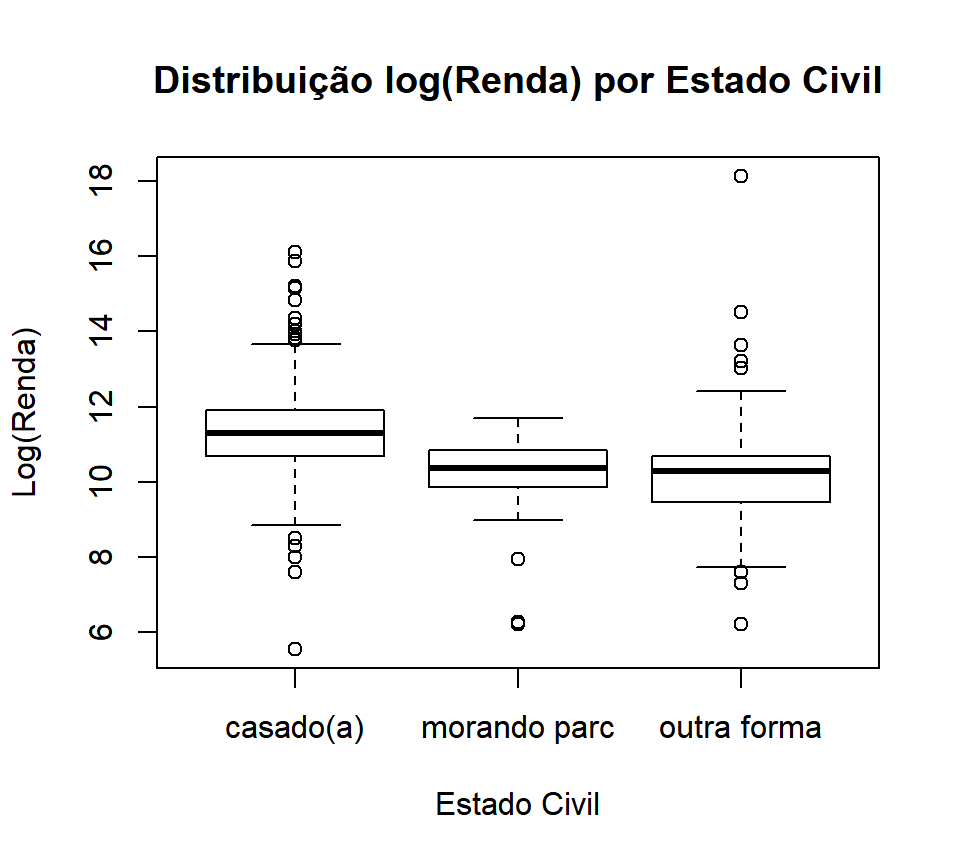

## Análise Descritiva - Log(Renda) x Etnia

A grande maioria dos entrevistados são brancos, seguidos, em ordem, dos negros, hispânicos e outros.

```
##           brancos negros hispânicos outros
## proporção      73     14          8      5
```

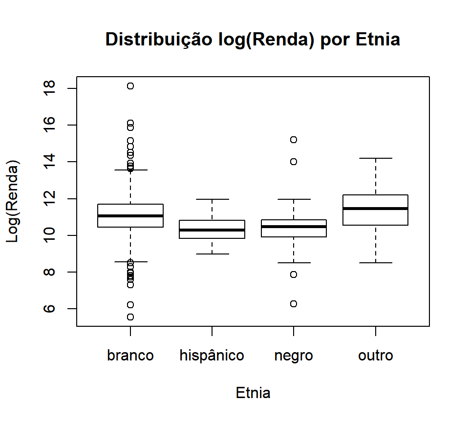

## LM Log(Renda)

```
##
## Call:
## lm(formula = log(Income) ~ as.factor(Gender) + as.factor(fx) +
##     as.factor(civil) + as.factor(etnia) + as.factor(escola),
##     data = BD)
##
## Residuals:
##     Min      1Q  Median      3Q     Max
## -6.3278 -0.4809  0.0494  0.5415  7.4913
##
## Coefficients:
##                              Estimate Std. Error t value Pr(>|t|)
## (Intercept)                   9.64697    0.31775  30.360  < 2e-16 ***
## as.factor(Gender)1            0.37997    0.20092   1.891 0.059204 .
## as.factor(fx)26 a 30          0.78643    0.29824   2.637 0.008639 **
## as.factor(fx)31 a 35          0.70929    0.30017   2.363 0.018527 *
## as.factor(fx)36 a 40          0.92778    0.28248   3.284 0.001097 **
## as.factor(fx)41 a 45          1.04047    0.27903   3.729 0.000215 ***
## as.factor(fx)46 a 50          1.05265    0.27115   3.882 0.000118 ***
## as.factor(fx)51 a 55          1.00851    0.28656   3.519 0.000474 ***
## as.factor(fx)56 a 60          0.78839    0.27876   2.828 0.004878 **
## as.factor(fx)61 a 65          1.14532    0.30246   3.787 0.000172 ***
## as.factor(fx)65 a 70          0.27222    0.33628   0.810 0.418623
## as.factor(fx)71 a 75          0.48181    0.38854   1.240 0.215566
## as.factor(fx)76 a 80          0.57504    0.54380   1.057 0.290834
## as.factor(fx)80 a 85          1.20052    0.64312   1.867 0.062552 .
## as.factor(civil)morando parc -0.53035    0.23756  -2.232 0.026045 *
## as.factor(civil)outra forma  -0.60256    0.17585  -3.427 0.000664 ***
## as.factor(etnia)hispânico    -0.28468    0.23191  -1.228 0.220209
## as.factor(etnia)negro        -0.26806    0.16565  -1.618 0.106268
## as.factor(etnia)outro         0.09263    0.25121   0.369 0.712478
## as.factor(escola)15 a 17      0.80887    0.11633   6.953 1.17e-11 ***
## as.factor(escola)2 a 10      -0.31854    0.23413  -1.360 0.174315
## ---
## Signif. codes:  0 '***' 0.001 '**' 0.01 '*' 0.05 '.' 0.1 ' ' 1
##
## Residual standard error: 1.19 on 479 degrees of freedom
## Multiple R-squared:  0.3004, Adjusted R-squared:  0.2712
## F-statistic: 10.29 on 20 and 479 DF,  p-value: < 2.2e-16
```

## LM Log(Renda) - Gráfico

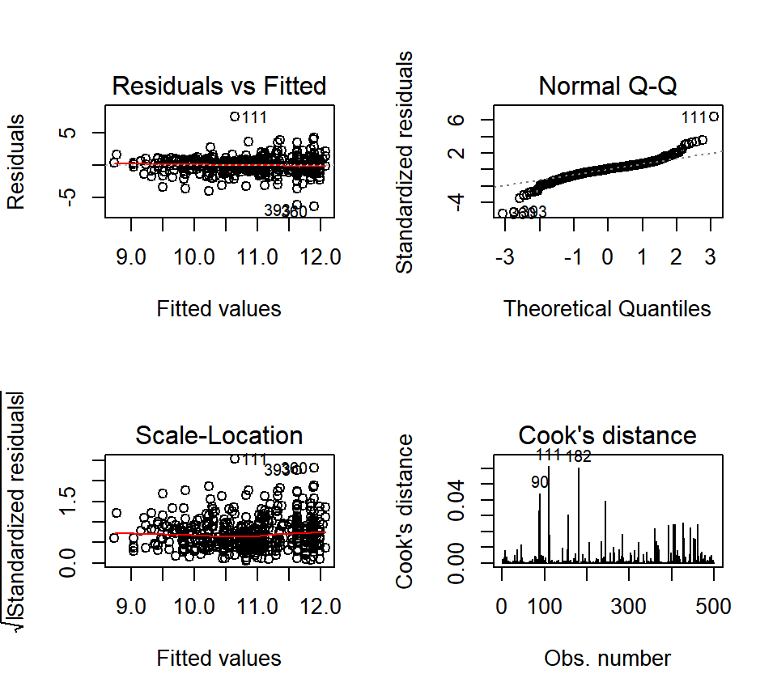

## GLM log(renda) - Gamma

Por fim, aplicamos um GLM utilizando a família Gamma e função de ligação identidade e obtemos um modelo bastante interessante.

deviance

```
## [1] 5.933787
```

```
##
## Call:
## glm(formula = log(Income) ~ as.factor(Gender) + as.factor(fx) +
##     as.factor(civil) + as.factor(etnia) + as.factor(escola),
##     family = Gamma(link = "identity"), data = BD)
##
## Deviance Residuals:
##      Min        1Q    Median        3Q       Max
## -0.67429  -0.04510   0.00342   0.04708   0.58410
##
## Coefficients:
##                              Estimate Std. Error t value Pr(>|t|)
## (Intercept)                   9.69640    0.28960  33.482  < 2e-16 ***
## as.factor(Gender)1            0.38056    0.18756   2.029 0.043004 *
## as.factor(fx)26 a 30          0.76791    0.27274   2.816 0.005071 **
## as.factor(fx)31 a 35          0.66648    0.27639   2.411 0.016267 *
## as.factor(fx)36 a 40          0.89936    0.26040   3.454 0.000602 ***
## as.factor(fx)41 a 45          0.98574    0.25627   3.847 0.000136 ***
## as.factor(fx)46 a 50          0.99791    0.24947   4.000 7.33e-05 ***
## as.factor(fx)51 a 55          0.94999    0.26627   3.568 0.000396 ***
## as.factor(fx)56 a 60          0.76627    0.25618   2.991 0.002923 **
## as.factor(fx)61 a 65          1.11222    0.28542   3.897 0.000111 ***
## as.factor(fx)65 a 70          0.17575    0.30620   0.574 0.566253
## as.factor(fx)71 a 75          0.37348    0.36317   1.028 0.304280
## as.factor(fx)76 a 80          0.50998    0.52880   0.964 0.335321
## as.factor(fx)80 a 85          0.97875    0.61561   1.590 0.112523
## as.factor(civil)morando parc -0.56544    0.22053  -2.564 0.010652 *
## as.factor(civil)outra forma  -0.62263    0.16844  -3.696 0.000244 ***
## as.factor(etnia)hispânico    -0.28274    0.22001  -1.285 0.199379
## as.factor(etnia)negro        -0.24497    0.15754  -1.555 0.120609
## as.factor(etnia)outro         0.07397    0.25956   0.285 0.775786
## as.factor(escola)15 a 17      0.80795    0.11515   7.016 7.82e-12 ***
## as.factor(escola)2 a 10      -0.31348    0.21483  -1.459 0.145167
## ---
## Signif. codes:  0 '***' 0.001 '**' 0.01 '*' 0.05 '.' 0.1 ' ' 1
##
## (Dispersion parameter for Gamma family taken to be 0.01167546)
##
##     Null deviance: 8.4408  on 499  degrees of freedom
## Residual deviance: 5.9338  on 479  degrees of freedom
## AIC: 1629.5
##
## Number of Fisher Scoring iterations: 5
```